# Drivers of rents

Nam Ngo - HUD

April 2024

Some preliminary results for the drivers of rent projects

# 1 Preliminary analysis

## 1.1 Time series

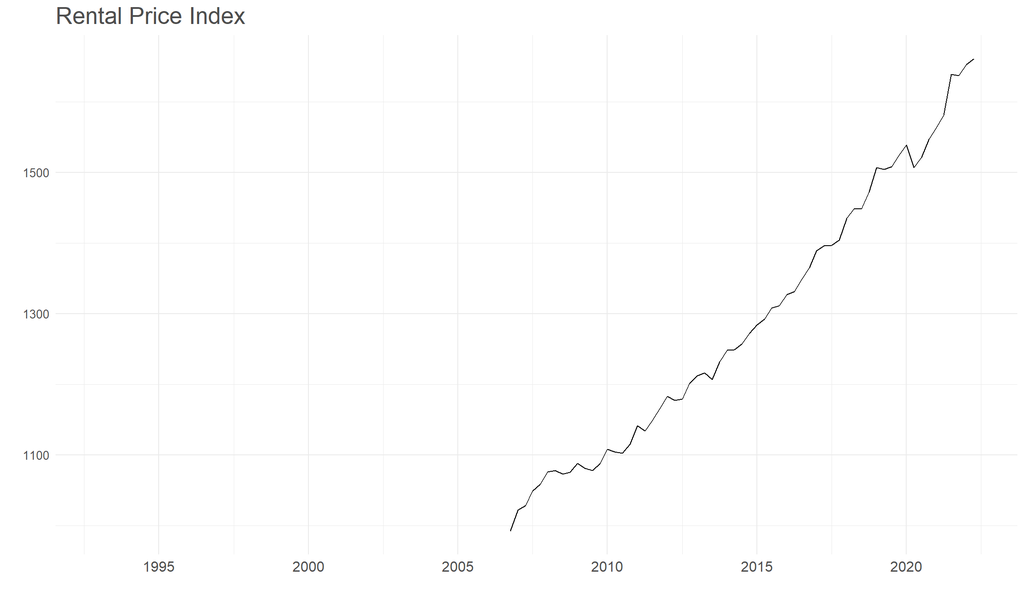

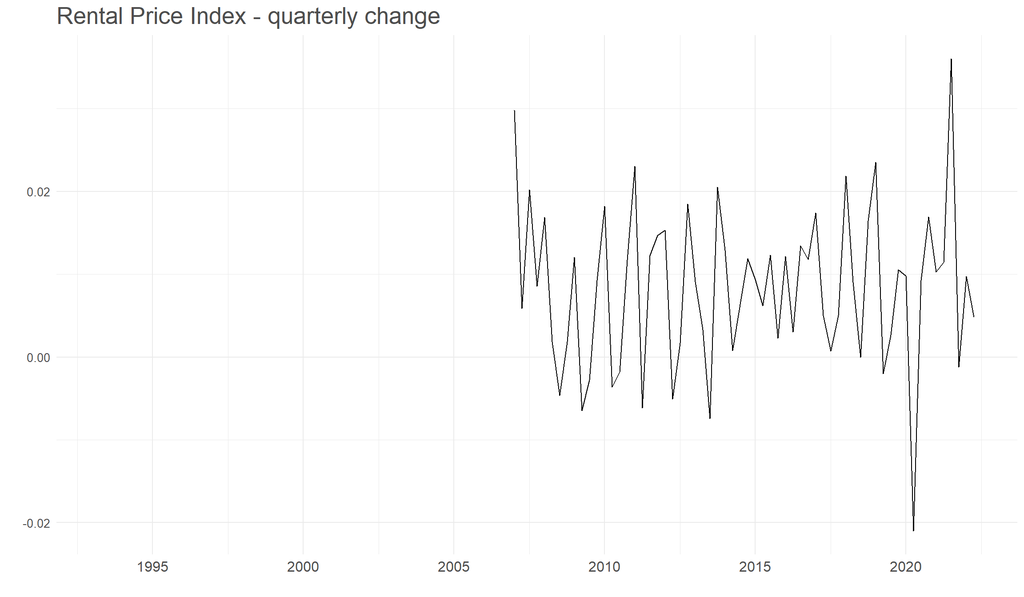

## 1.2 Seasonality

There’s some seasonal pattern in the Rental Price Index series, i.e high in Q1 and low in Q3, however the magnitude is not significant. A lot of the underlying seasonality has already been taken out by the fixed effects method.

Note:

- If quarterly inflation is used as the explanatory variable, then include quarter dummies to control for the residual seasonality pattern
- If annual inflation is used then quarterly dummies are optional

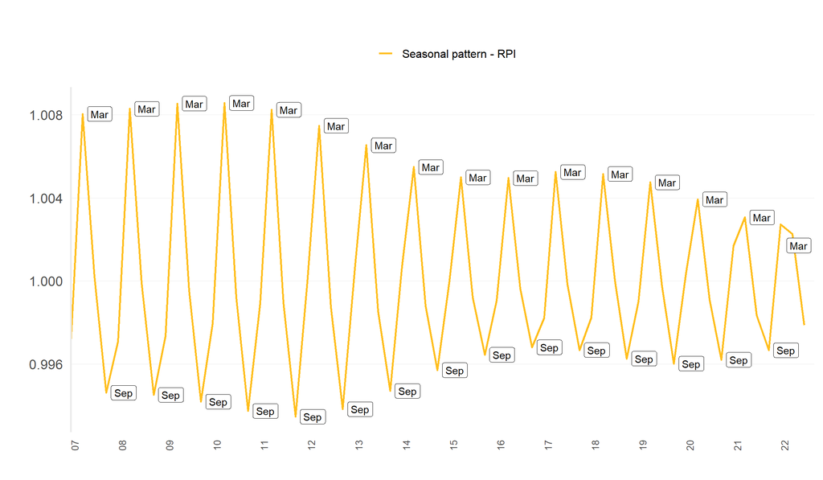

[figure not shown]

## 1.3 Lag selection - Rent growth

The autocorrelation function and partial autocorrelation function suggest that lag rent growth of at least order 1 should be included as explanatory variables

### 1.3.1 Quarterly change

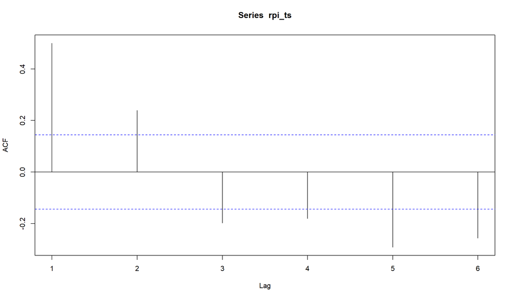

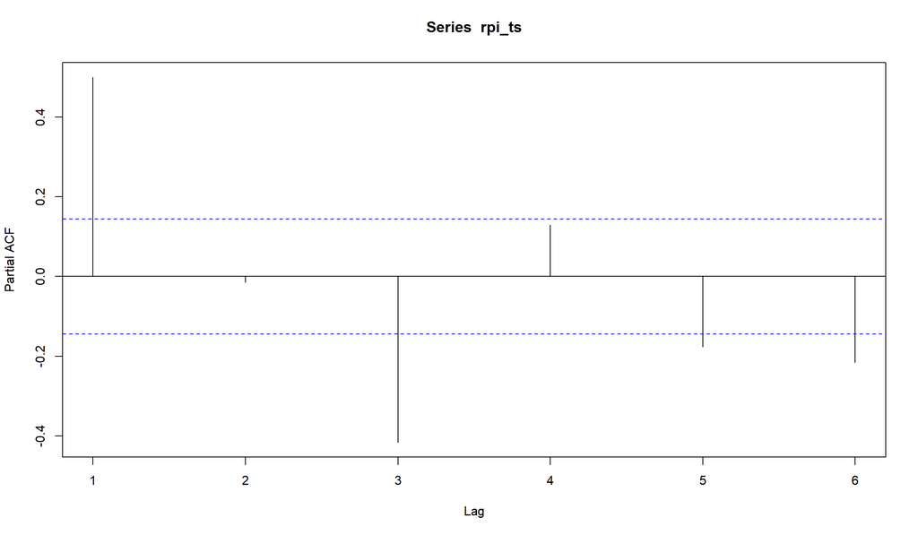

### 1.3.2 Annual change

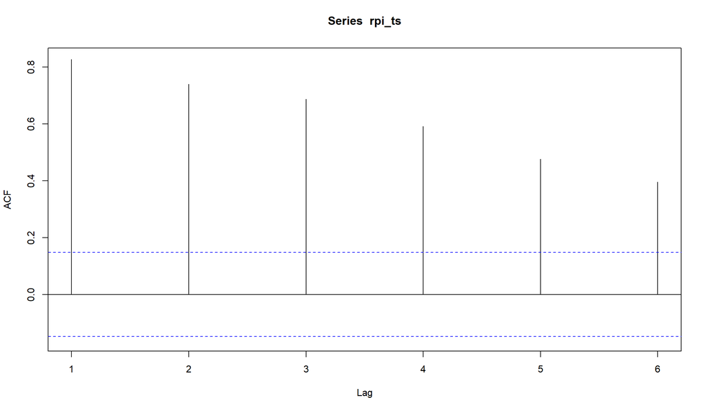

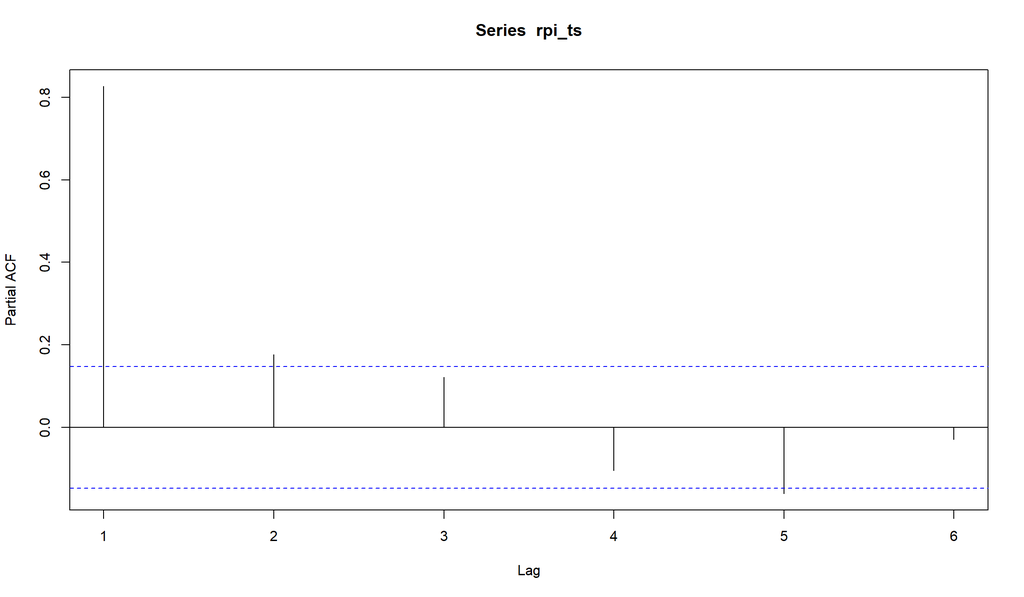

### 1.3.3 Correlation matrix

[figure not shown]

## 1.4 Results

### 1.4.1 Annual rent inflation, quarterly frequency vs wage growth (average weekly earnings)

- Measure of relative supply and demand: People per dwelling (demeanded)
- Q1-2006 to Q4-2021

Rent inflation (annual)

Predictors

Estimates

CI

p

Rent inflation (lagged)

0.647 ***

0.448 – 0.847

**<0.001**

Wage growth (lagged)

0.165

-0.064 – 0.394

0.155

People per dwelling (demeaned, lagged)

-13.920

-35.230 – 7.389

0.195

Floating mortgage rate (lagged)

-0.054

-0.307 – 0.199

0.672

Unemployment rate (lagged)

0.139

-0.345 – 0.623

0.568

Wage growth x People per dwelling

5.917 **

0.727 – 11.107

**0.026**

Observations

58

R<sup>2</sup> / R<sup>2</sup> adjusted

0.693 / 0.635

- p<0.1 ** p<0.05 *** p<0.01

Replacing mortgage rate with change in mortgage rate suggests that the speed of rising/decreasing mortgage rate is more important for explaining rent inflation (through declining/rising homeownership rate channel)

Rent inflation (annual)

Predictors

Estimates

CI

p

Rent inflation (lagged)

0.480 ***

0.246 – 0.714

**<0.001**

Wage growth (lagged)

0.239 **

0.025 – 0.454

**0.030**

People per dwelling (demeaned, lagged)

-10.733

-30.632 – 9.167

0.284

Change in floating mortgage rate (lagged)

0.300 **

0.036 – 0.565

**0.027**

Unemployment rate (lagged)

0.166

-0.235 – 0.568

0.409

Wage growth x People per dwelling

5.387 **

0.492 – 10.282

**0.032**

Observations

58

R<sup>2</sup> / R<sup>2</sup> adjusted

0.722 / 0.670

- p<0.1 ** p<0.05 *** p<0.01

### 1.4.2 Alternative measure of relative supply and demand

Rent inflation (annual)

Predictors

Estimates

CI

p

Rent inflation (lagged)

0.618 ***

0.387 – 0.849

**<0.001**

Wage growth (lagged)

0.838 **

0.044 – 1.632

**0.039**

Vacancy rate (lagged)

0.238

-0.884 – 1.359

0.672

Change in floating mortgage rate (lagged)

0.008

-0.380 – 0.396

0.968

Unemployment rate (lagged)

0.178

-0.271 – 0.628

0.429

Wage growth x Vacancy rate

-0.171 *

-0.375 – 0.034

0.099

Observations

58

R<sup>2</sup> / R<sup>2</sup> adjusted

0.674 / 0.613

Rent inflation (annual)

Predictors

Estimates

CI

p

Rent inflation (lagged)

0.637 ***

0.423 – 0.850

**<0.001**

Wage growth (lagged)

0.225 **

0.043 – 0.407

**0.016**

Change in median vacant time (lagged)

0.296

-0.082 – 0.674

0.122

Change in floating mortgage rate (lagged)

-0.070

-0.269 – 0.129

0.485

Unemployment rate (lagged)

0.059

-0.252 – 0.369

0.706

Wage growth x Change in median vacant time

-0.101 **

-0.188 – -0.015

**0.023**

Observations

58

R<sup>2</sup> / R<sup>2</sup> adjusted

0.699 / 0.643

- p<0.1 ** p<0.05 *** p<0.01

Household income growth (to be added)